# Simple plotting exercise

Here is some code to make some basic plots and differentiate them up by a categorical variable (also called a **factor** variable in R).

First, we will clear the memory and load in the `tidyverse` package, which we will need for plotting. The `tidyverse` is a covenient collection of the packages we will need to tidy and plot our data. We read in a data file, in this case a comma separate value file (`csv`).

Now, we will load in a dataset.

The data used are from Hart, O’Hara, and Sirianni (2017) “The Effect of Sustainability Commitments on College Admissions: Evidence from the Presidents’ Climate Commitment” A brilliant paper that is currently being drooled over by referees at *JEEM*.

This data has two time series in it, showing the average 75th percentile SAT score for each year for each type of school, public vs private. We use `ggplot()`, a package developed by Hadley Wickham, to plot our data. The `gg` in `ggplot` stands for Grammar of Graphics, which we employ to specify the different characteristics of our graphs.

We start by making a simple scatterplot of the points in the data.

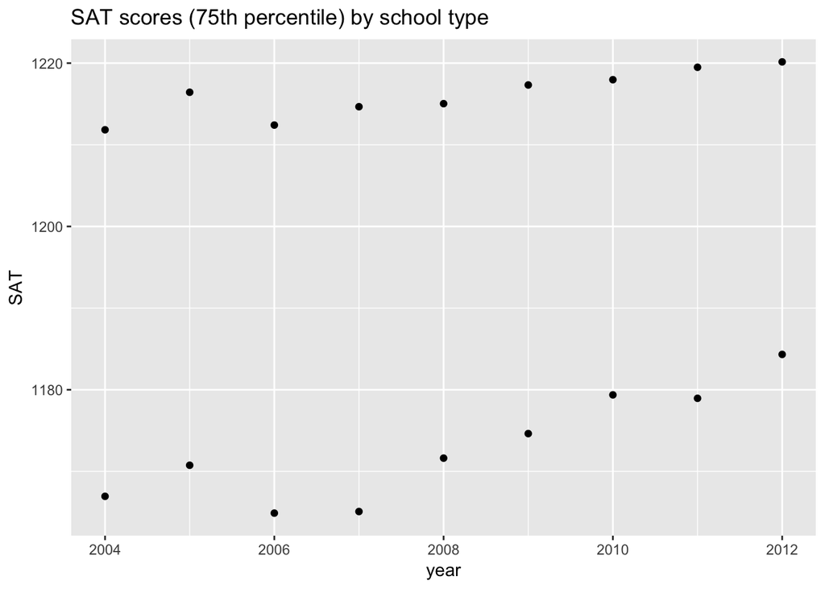

The dataframe is the first argument of the `ggplot()` command.

The second argument is a an argument `aes()` for *aesthetics*. What are aesthetic? The aesthetics of the graph:

- Specify the variables on the $x$ and $y$ axes
- Specify whether to attribute colors to different characteristics, e.g. later saying `color = SchoolType`
- Specify whether to attribute different fills (e.g. for columns) to different categories, e.g. `fill = SchoolType` (if we had bars or other types of plots)
- Specify whether to attribite different *shapes* to different categories, e.g. public schools given stars and private schools triangles
- Notice that editing the `aes()` function in the original `ggplot()` call results in changes to *all* subsequent graph properties. This is *good* because it can make change a lot of properties quick, but *bad* if we only want to edit the properties of one layer of the graph.

But just calling on `ggplot()` doesn’t result in an actual graph we can interpret until we tell it what *kind* of plot we want. In the case above, we wanted a scatterplot.

`ggplot()` operates by using *layers* to add different aspects to graphs (similar to what you do if you edit a photo in PhotoShop). Layers incorporate the following ideas:

- a layer of dots, lines, bars to produce graphs
- a layer for a graph title, axis labels
- annotations to the different points on the graphs, e.g. adding $R^2 = 0.92$ to a particular coordinate in a figure
- editing the legend for the graph

To add a layer to our plots, we need to end the *preceding* line with a `+` sign to tell `ggplot()` that it’s job isn’t done yet. So our code will look like the following: `ggplot(sat.by.type, aes(x = year, y = avg.sat)) +` (the plus sign indicating something is about to come up). If you end a line of code with a plus sign, then R (and `ggplot()`) expect you to put something there, so if you put that into your *console* it’ll just sit there waiting for you to add something or to hit [esc] to break the process.

The different kinds of graphs are called `geom_`s in ggplot parlance. A scatterplot requires us to use `geom_point()`. Notice that because we have *already* specified what the x and y variables are, we do *not* need to do so again in the `geom_point()` function Later, though, we will add attributes in the `geom_point()` function to specify particular attributes of the scatter plot that we want to define.

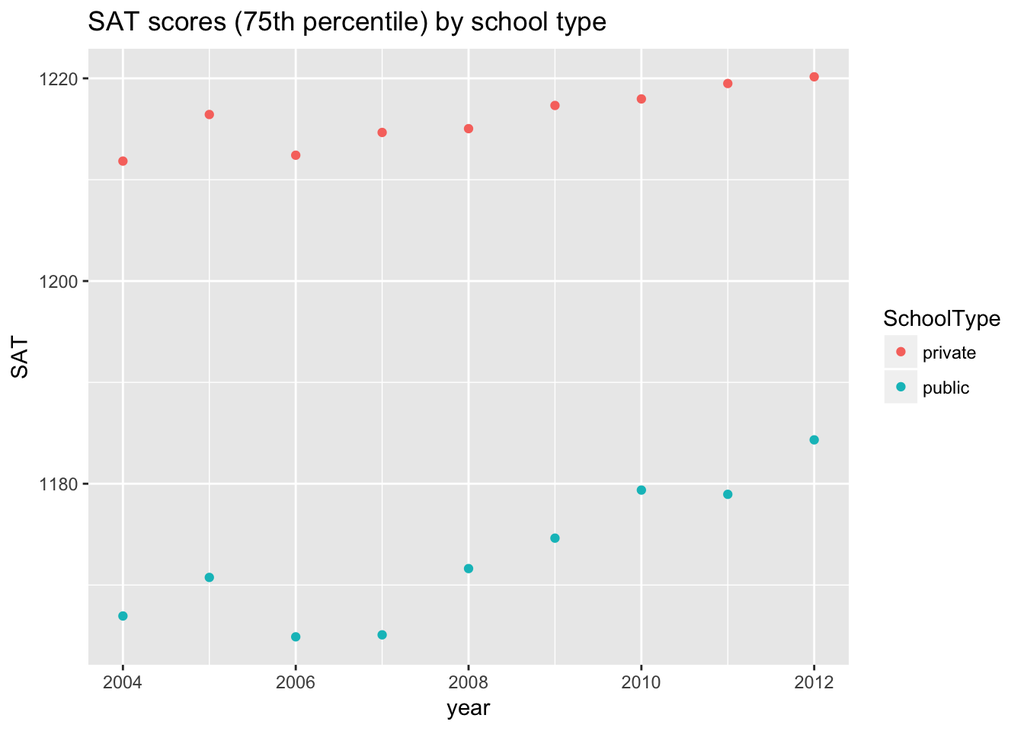

Suppose we want to make a simple line graph to compare the trends of SAT scores over time in the different types of schools.

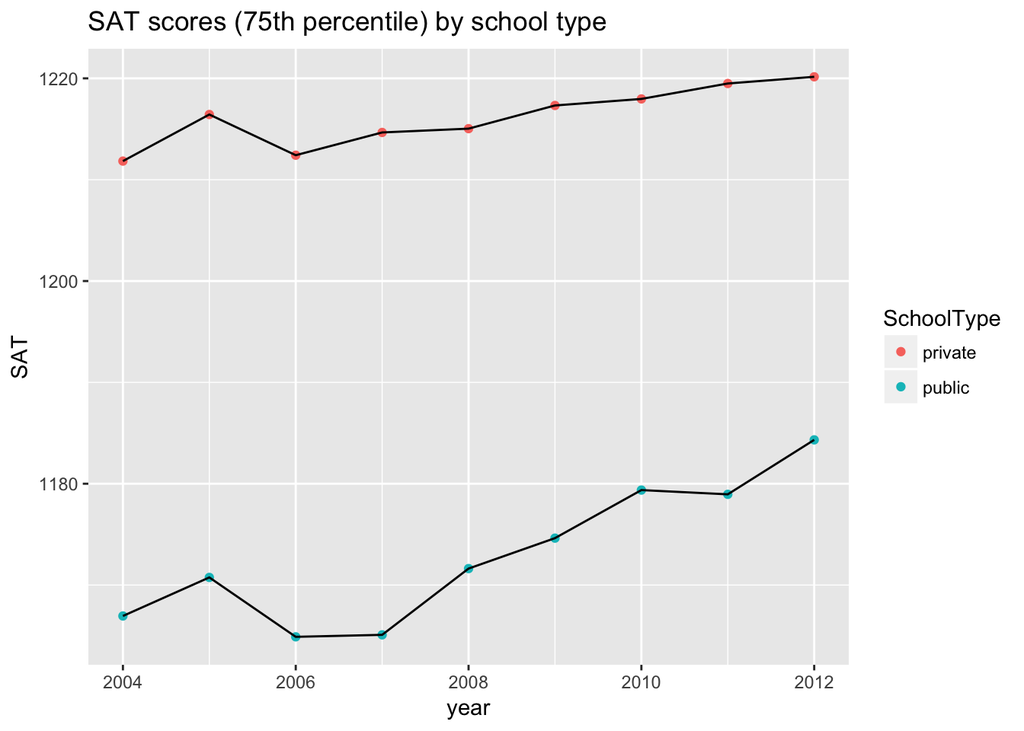

But what’s happening above?

- We’ve added `geom_line()` to add lines to our time series.
- But the lines are black because we didn’t specify a color aesthetic in the `geom_line()` function.
- There are two ways to get around this
- add `aes(color = SchoolType)` to the `geom_line()` function (OK if we only want color to apply to the lines)
- add `color = SchoolType` to the `aes()` call in the original `ggplot()` call (if we want the color grouping to apply to *all* subsequent geoms - so often more efficient if we want to change an aspect of all aesthetics of our graph)

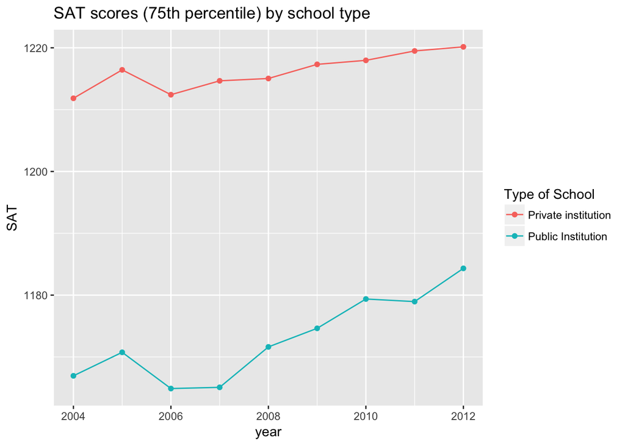

```r
###  Make a line plot of average SAT scores by school type
ggplot(sat.by.type, aes(x = year, y = avg.sat, group = SchoolType, color = SchoolType)) +
   geom_point() +
   geom_line() +
  labs(title = "SAT scores (75th percentile) by school type", y = "SAT") +
  scale_color_discrete(name = "Type of School",
                       breaks = c("private", "public"),
                       labels = c("Private institution", "Public Institution"))
```